# Analyzing resting-state EEG and Spelling Performance in Young Adults (Gamma)

Leandro Ledesma

2024-12-24

### Universal block code settings

```r
knitr::opts_chunk$set(echo = FALSE)
knitr::opts_chunk$set(message = FALSE)
knitr::opts_chunk$set(comment = NULL)
knitr::opts_chunk$set(warning = FALSE)
```

### Load in the data manipulation packages first

### Index subjects by those that met the requirements

- No self-report injury
- No Epilepsy
- Removing missing data
- No one below ‘IQ’ of 70 (more than 2 SD below the mean)
- Extremely poor spellers (more than 3 SD below the mean)
- Issues with EEG recordings
- Did not survive EEG cleaning

### Missing data

- All data should be present based on the index from the previous section

This is an automated response: The current dataset has the dimensions 449 x 38 . Below is a frequency table showing the number of missing data for each variable.

[output not shown]

This is an automated response: Our final sample size is n= 449

## Research Question

- We are interested in investigating spelling performance as a predictor of EEG activity. We hypothesize that spelling ability will result in differences in brain activity while controlling for covariates like Age, Group (Bio vs Ins), and topography.

## Descriptive statistics of the data

We can use the describe() function from the psych package to give us descriptive statistics from the variables that will be incorporated into the model. We will create 3 tables. The first will contain information about the continuous predictors. The next will have the frequency of the categorical variables. Lastly we will have a table for the resting-state EEG frequency bands.

We will be creating models for 4 differenet frequency bands (delta, theta, alpha, beta), thus, four datasets will be created where only information related to a specific frequency band are present.

### Descriptives of our data

|  | vars | n | mean | sd | median | trimmed | mad | min | max | range | skew | kurtosis | se |
| --- | --- | --- | --- | --- | --- | --- | --- | --- | --- | --- | --- | --- | --- |
| ID | 1 | 449 | 55103.450 | 25813.478 | 56234.000 | 55149.798 | 31678.714 | 10053.000 | 99982.000 | 89929.000 | -0.038 | -1.165 | 1218.213 |
| Age | 2 | 449 | 20.269 | 4.438 | 19.000 | 19.546 | 2.965 | 15.000 | 36.000 | 21.000 | 1.376 | 1.350 | 0.209 |
| IQRS | 3 | 449 | 30.866 | 5.374 | 32.000 | 31.205 | 4.448 | 18.000 | 42.000 | 24.000 | -0.542 | -0.323 | 0.254 |
| Total_SpellingError | 4 | 449 | 13.379 | 8.620 | 12.000 | 12.598 | 8.896 | 0.000 | 41.000 | 41.000 | 0.733 | -0.010 | 0.407 |
| frontal_avgdelta_fftx | 5 | 449 | 0.046 | 0.025 | 0.040 | 0.042 | 0.018 | 0.009 | 0.218 | 0.209 | 2.562 | 11.100 | 0.001 |
| frontal_avgtheta_fftx | 6 | 449 | 0.021 | 0.016 | 0.016 | 0.018 | 0.009 | 0.004 | 0.142 | 0.138 | 2.770 | 11.643 | 0.001 |
| frontal_avgalpha_fftx | 7 | 449 | 0.049 | 0.044 | 0.035 | 0.042 | 0.030 | 0.003 | 0.324 | 0.320 | 2.341 | 8.325 | 0.002 |
| frontal_avgbeta_fftx | 8 | 449 | 0.005 | 0.004 | 0.004 | 0.005 | 0.002 | 0.001 | 0.041 | 0.040 | 4.045 | 28.801 | 0.000 |
| temporal_avgdelta_fftx | 9 | 449 | 0.039 | 0.021 | 0.034 | 0.036 | 0.016 | 0.008 | 0.185 | 0.177 | 2.149 | 7.784 | 0.001 |
| temporal_avgtheta_fftx | 10 | 449 | 0.023 | 0.019 | 0.017 | 0.019 | 0.010 | 0.004 | 0.154 | 0.149 | 3.077 | 13.289 | 0.001 |
| temporal_avgalpha_fftx | 11 | 449 | 0.040 | 0.028 | 0.033 | 0.036 | 0.023 | 0.003 | 0.151 | 0.148 | 1.258 | 1.459 | 0.001 |
| temporal_avgbeta_fftx | 12 | 449 | 0.007 | 0.005 | 0.006 | 0.006 | 0.003 | 0.001 | 0.045 | 0.043 | 2.678 | 11.348 | 0.000 |
| parietal_avgdelta_fftx | 13 | 449 | 3953619848481581772468400824486806000222206286486446042608446042888022442444868806262066868248884488688042846086862264002264662446486684248064.000 | 83775702610793291400448804884266286482220846208008282824684068800804402260840084404664020468266446006682488624864002024446046460002684666624824.000 | 0.027 | 0.029 | 0.013 | 0.008 | 1775175311968230158988426068262884624228402220200668608422826600266642800648642606240208060246204606684046260028424800084628222486644266224800280.000 | 1775175311968230158988426068262884624228402220200668608422826600266642800648642606240208060246204606684046260028424800084628222486644266224800280.000 | NaN | NaN | 3953619848481581095668602282884226288024446484262460624484824480026888664884228426624202288004868046444426060868442406006026260220828200664480.000 |
| parietal_avgtheta_fftx | 14 | 449 | 3953619848481603433008888864622828642404260248460240682820046426668468428268408802200488626246246480664246888802222688484628866800282246226602.000 | 83775702610793757120060608028884468680046602420846206246608208422664664860444604206480684826604286208804842662046868426602046004026260404800046.000 | 0.014 | 0.017 | 0.010 | 0.002 | 1775175311968239863268062882448866420440008424666422208248226660806042408040626246228080244226422682800608228246606806288428240062460604408420484.000 | 1775175311968239863268062882448866420440008424666422208248226660806042408040626246228080244226422682800608228246606806288428240062460604408420484.000 | NaN | NaN | 3953619848481603433008888864622828642404260248460240682820046426668468428268408802200488626246246480664246888802222688484628866800282246226602.000 |
| parietal_avgalpha_fftx | 15 | 449 | 3953619848481603433008888864622828642404260248460240682820046426668468428268408802200488626246246480664246888802222688484628866800282246226602.000 | 83775702610793757120060608028884468680046602420846206246608208422664664860444604206480684826604286208804842662046868426602046004026260404800046.000 | 0.052 | 0.063 | 0.047 | 0.002 | 1775175311968239863268062882448866420440008424666422208248226660806042408040626246228080244226422682800608228246606806288428240062460604408420484.000 | 1775175311968239863268062882448866420440008424666422208248226660806042408040626246228080244226422682800608228246606806288428240062460604408420484.000 | NaN | NaN | 3953619848481603433008888864622828642404260248460240682820046426668468428268408802200488626246246480664246888802222688484628866800282246226602.000 |
| parietal_avgbeta_fftx | 16 | 449 | 3953619848481625772462064426466420220060888222662206820482468466200048022642428024846664226248464864846028406086202660422820022422048622428424.000 | 83775702610794222840080022882000648882866468642088806664648448064424022286048224808222248068062022444826240466224424622868044646842806280084208.000 | 0.004 | 0.004 | 0.002 | 0.001 | 1775175311968249914142206662208644484604062448046224242280484886240266084008846466642042022866664220480668464806400628284226624448882002280202666.000 | 1775175311968249914142206662208644484604062448046224242280484886240266084008846466642042022866664220480668464806400628284226624448882002280202666.000 | NaN | NaN | 3953619848481625095268866884868840408866208220428220202248600804642804444042888608208002446244608482640642868868882860466082620666080848844240.000 |
| occipital_avgdelta_fftx | 17 | 449 | 0.064 | 0.050 | 0.049 | 0.055 | 0.027 | 0.010 | 0.470 | 0.460 | 3.311 | 17.598 | 0.002 |
| occipital_avgtheta_fftx | 18 | 449 | 0.037 | 0.035 | 0.026 | 0.031 | 0.020 | 0.005 | 0.289 | 0.284 | 2.781 | 11.147 | 0.002 |
| occipital_avgalpha_fftx | 19 | 449 | 0.190 | 0.189 | 0.136 | 0.157 | 0.128 | 0.003 | 1.294 | 1.291 | 2.265 | 6.919 | 0.009 |
| occipital_avgbeta_fftx | 20 | 449 | 0.010 | 0.007 | 0.008 | 0.009 | 0.004 | 0.002 | 0.072 | 0.070 | 3.810 | 24.429 | 0.000 |
| frontal_avgdelta_welchx | 21 | 449 | 5.450 | 2.831 | 4.863 | 5.084 | 2.118 | 1.148 | 28.217 | 27.070 | 2.627 | 13.337 | 0.134 |
| frontal_avgtheta_welchx | 22 | 449 | 2.119 | 1.502 | 1.670 | 1.849 | 0.930 | 0.419 | 13.361 | 12.942 | 2.671 | 10.970 | 0.071 |
| frontal_avgalpha_welchx | 23 | 449 | 4.787 | 4.377 | 3.492 | 4.052 | 2.964 | 0.336 | 29.755 | 29.419 | 2.205 | 6.801 | 0.207 |
| frontal_avgbeta_welchx | 24 | 449 | 0.532 | 0.356 | 0.441 | 0.478 | 0.198 | 0.132 | 4.156 | 4.023 | 3.987 | 28.726 | 0.017 |
| temporal_avgdelta_welchx | 25 | 449 | 4.503 | 2.256 | 3.981 | 4.201 | 1.760 | 0.981 | 19.615 | 18.634 | 1.894 | 6.440 | 0.106 |
| temporal_avgtheta_welchx | 26 | 449 | 2.301 | 1.834 | 1.718 | 1.970 | 1.020 | 0.455 | 14.966 | 14.511 | 2.974 | 12.703 | 0.087 |
| temporal_avgalpha_welchx | 27 | 449 | 3.948 | 2.855 | 3.176 | 3.561 | 2.317 | 0.350 | 15.159 | 14.808 | 1.268 | 1.435 | 0.135 |
| temporal_avgbeta_welchx | 28 | 449 | 0.742 | 0.492 | 0.615 | 0.664 | 0.330 | 0.111 | 4.469 | 4.358 | 2.678 | 12.073 | 0.023 |
| parietal_avgdelta_welchx | 29 | 449 | 3.875 | 2.530 | 3.181 | 3.463 | 1.491 | 1.041 | 23.740 | 22.699 | 3.072 | 15.055 | 0.119 |
| parietal_avgtheta_welchx | 30 | 449 | 2.128 | 2.151 | 1.398 | 1.695 | 0.937 | 0.267 | 15.788 | 15.521 | 3.009 | 12.016 | 0.101 |
| parietal_avgalpha_welchx | 31 | 449 | 7.209 | 7.200 | 4.708 | 5.938 | 4.372 | 0.238 | 57.900 | 57.662 | 2.386 | 8.610 | 0.340 |
| parietal_avgbeta_welchx | 32 | 449 | 0.471 | 0.298 | 0.392 | 0.426 | 0.228 | 0.074 | 1.895 | 1.820 | 1.572 | 2.942 | 0.014 |
| occipital_avgdelta_welchx | 33 | 449 | 7.216 | 5.077 | 5.697 | 6.358 | 3.046 | 1.223 | 45.797 | 44.574 | 2.989 | 14.604 | 0.240 |
| occipital_avgtheta_welchx | 34 | 449 | 3.815 | 3.559 | 2.651 | 3.134 | 1.963 | 0.514 | 29.697 | 29.183 | 2.811 | 11.459 | 0.168 |
| occipital_avgalpha_welchx | 35 | 449 | 18.270 | 18.737 | 12.160 | 14.902 | 11.824 | 0.343 | 113.983 | 113.640 | 2.210 | 6.219 | 0.884 |
| occipital_avgbeta_welchx | 36 | 449 | 1.051 | 0.801 | 0.848 | 0.927 | 0.432 | 0.209 | 9.649 | 9.440 | 4.452 | 35.678 | 0.038 |

```
  F   M
257 192
```

```
 BF  IC
246 203
```

### FFT vs Pwelch

- Let’s compare the variance of power between FFT and Welch Method approach
- Must fix issue with parietal data in fftx- right now the comparison is not meaningful
- For right now we will conduct the rest of the analysis for Welch’s Method

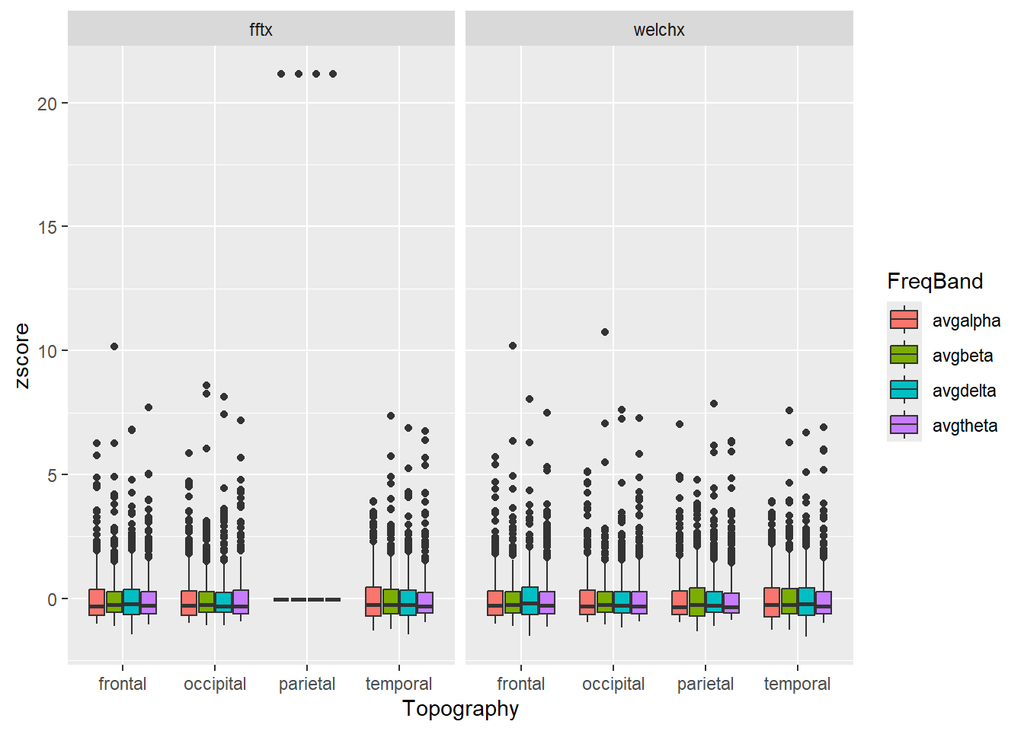

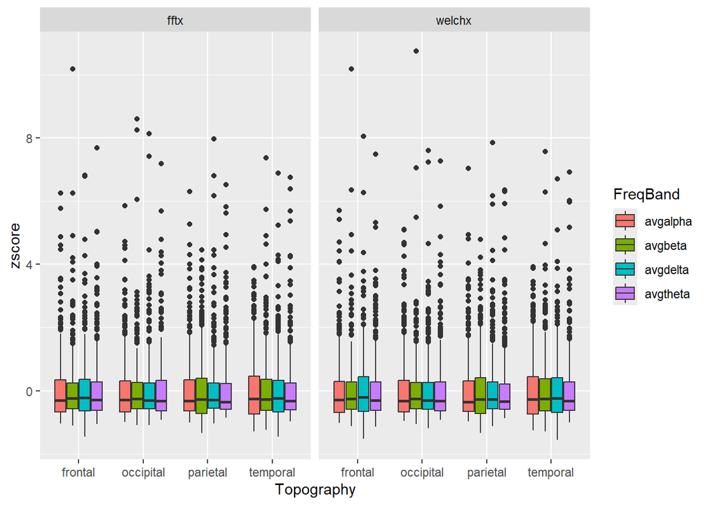

### Visualizing all continuous variables as histograms (Z-scores)

- This drives home the message that the outcome variable is highly skewed to the right in all possible combinations of FB and Topography.

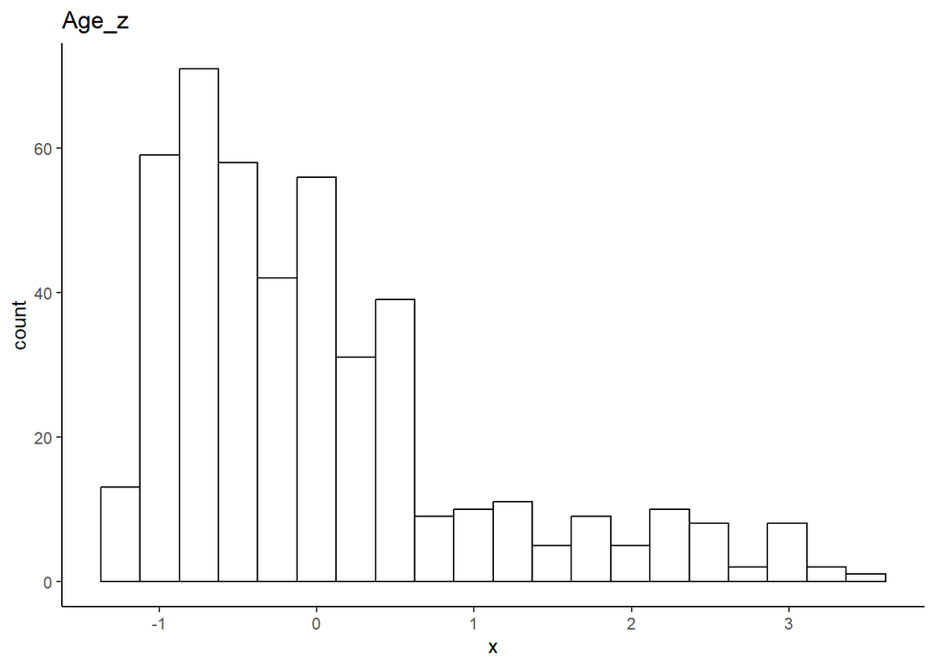

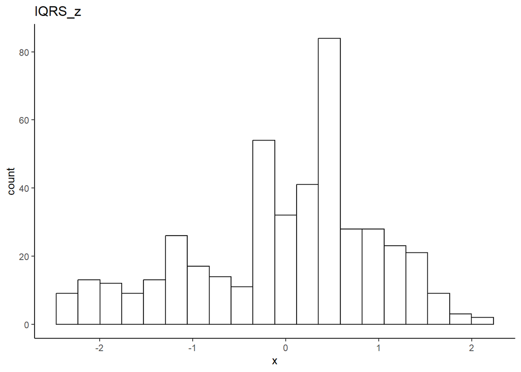

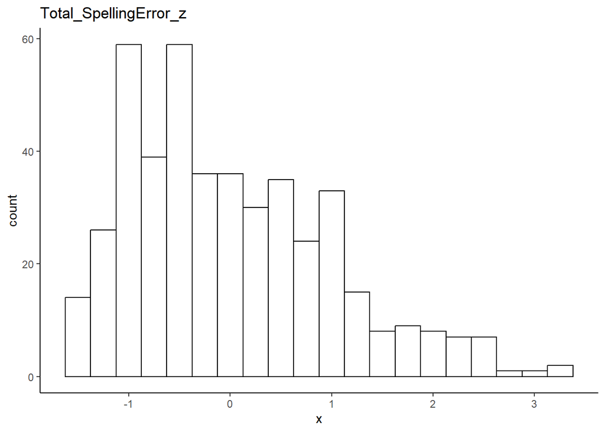

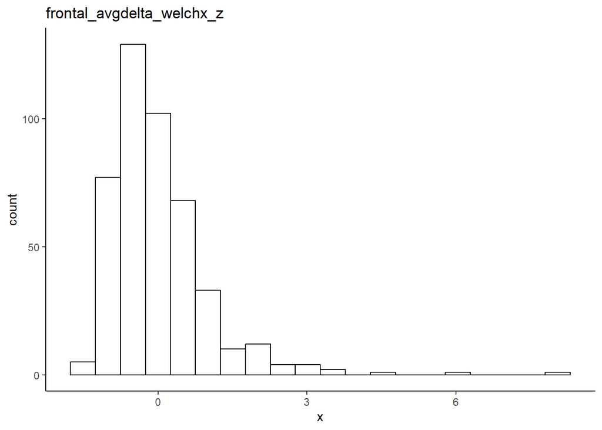

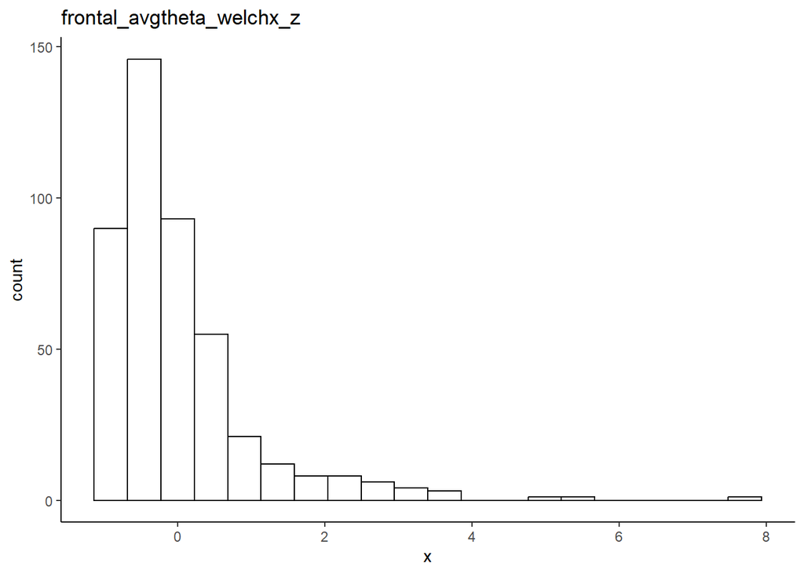

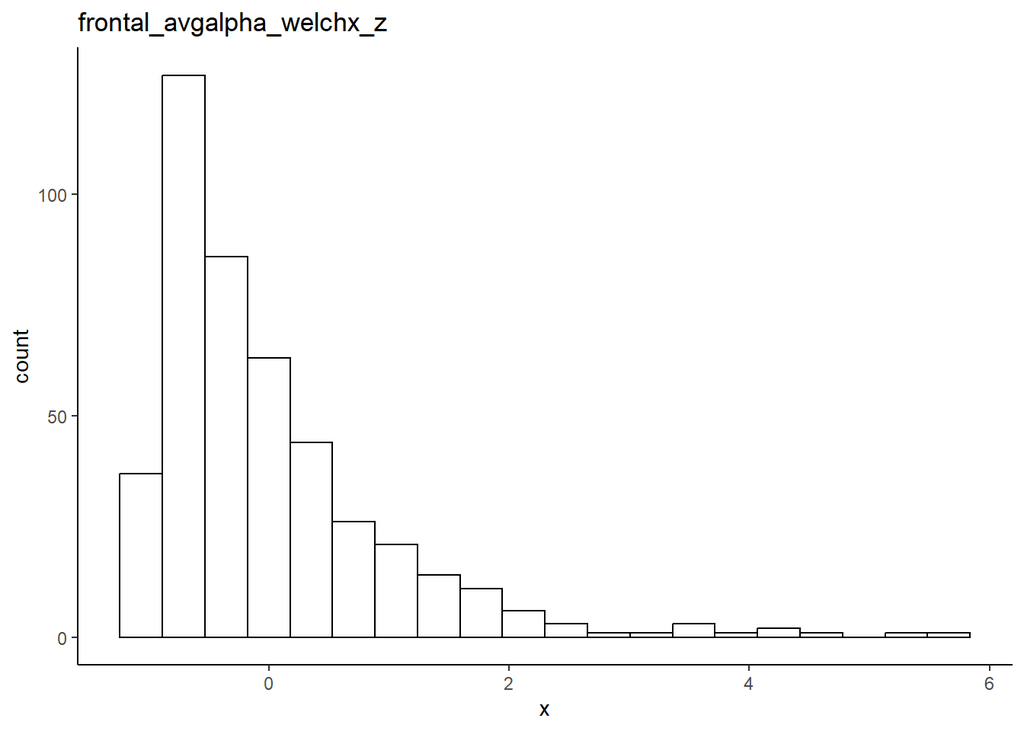

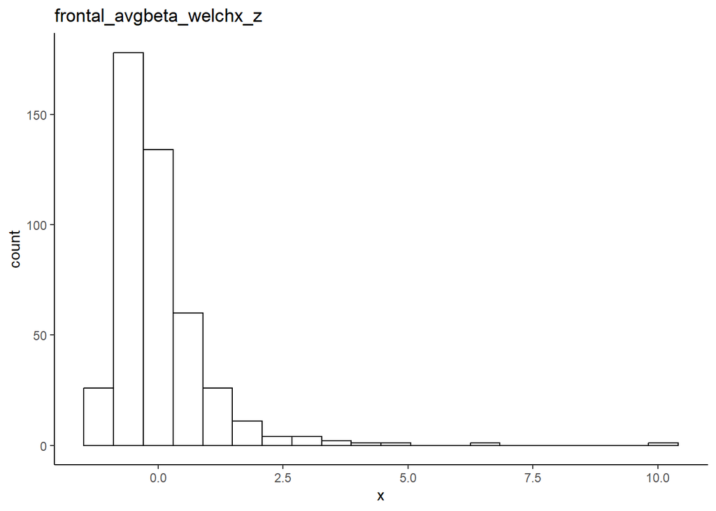

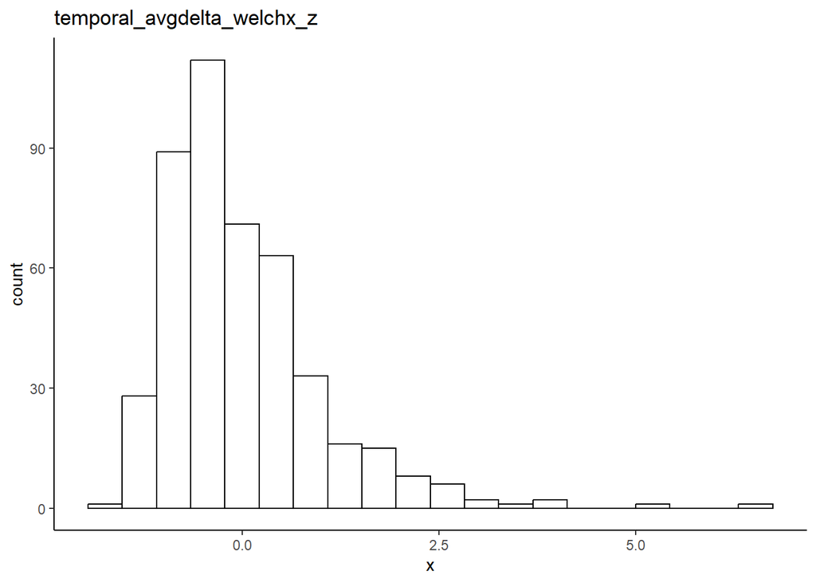

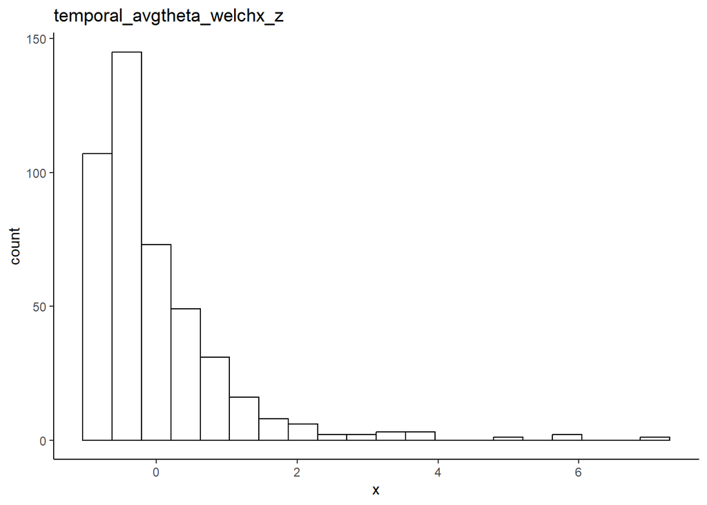

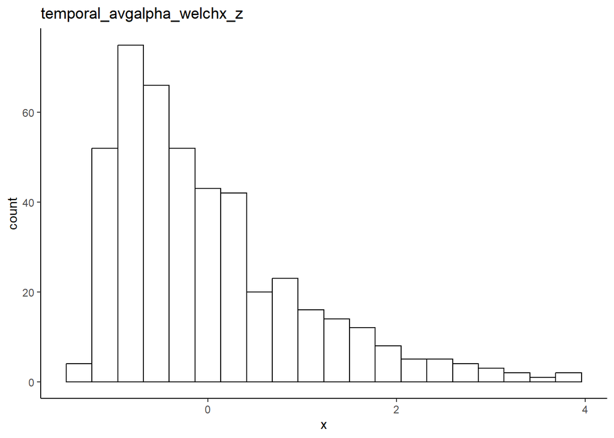

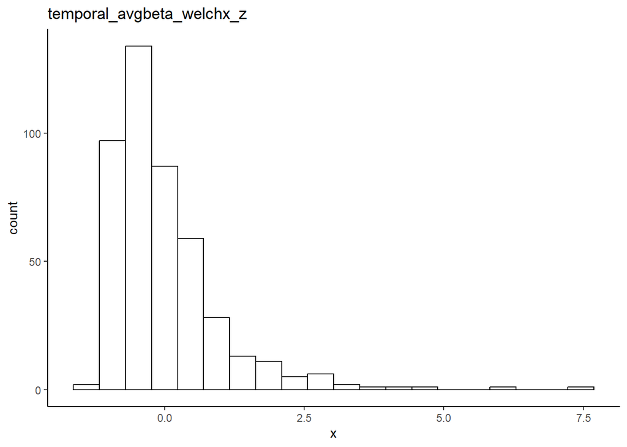

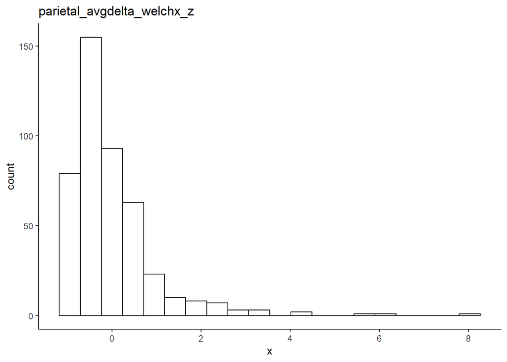

[7 more figures not shown]

### Testing for Multicollinearity

- We need to drop predictors that are highly correlated with each other
- Raw scores and total spelling error is kinda high but I think okay

```
                            Age        IQRS Total_SpellingError
Age                  1.00000000  0.09727325          -0.2088876
IQRS                 0.09727325  1.00000000          -0.6123482
Total_SpellingError -0.20888759 -0.61234825           1.0000000
```

### Check for independence between categorical variables

P-value is significant. It seems there are more females who were raised in biological families than males. This may not be as big of a deal as initially thought.

```
     Group
Sex    BF  IC Sum
  F   154 103 257
  M    92 100 192
  Sum 246 203 449
```

```
   Group
Sex    BF    IC
  F 0.343 0.229
  M 0.205 0.223
```

```
    Pearson's Chi-squared test with Yates' continuity correction

data:  contingency.table
X-squared = 5.9191, df = 1, p-value = 0.01498
```

### Preparing Data for Modeling

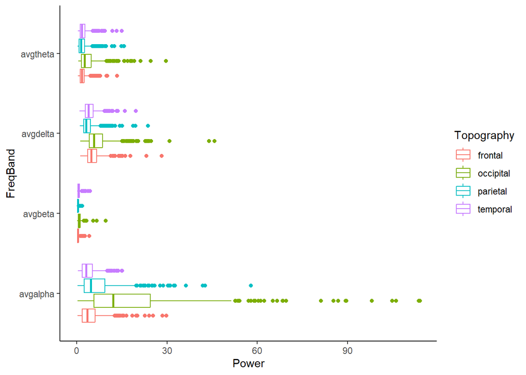

### Running our models

As mentioned, we are interested in how spelling performance may potentially influence electrical brain activity. To do this, we will be creating a **generalized linear mixed effects model (GLMM)** with a gamma distribution and **log** link function. This is because the distribution of the outcome power (which is a value representing averaged amplitudes within a frequency range/band squared) is positive and skewed to the right, which will produced skewed residuals. A Gamma distribution can better fit our data. Additionally, the introduction of topographical regions as a factor requires subjects to have their own random intercept. This is because we may expect brain regions to be more similar to each other within a person than across- thus, this needs to be taken into account by introducing subjects as a random effect.

The log link part is important and different from a logit link. The similarity is that exp() is used to represent these values into a number that is easier to understand. For the ‘log’ link, exp() converts it into a **raw score**- so in a way, it seems that exp() estimates is like turned them back into regular estimates that can be interpreted linearly (as one unit increase we expect this increase for the outcome) instead of as a probability. This is information obtain from ChatGPT.

We will use model comparison to see which model would be the best to interpret- however, if the model of best fit is too difficulty/complex, then we may chose the second best model.

```
# Intraclass Correlation Coefficient

    Adjusted ICC: 0.336
  Unadjusted ICC: 0.336
```

```
Data: data3
Models:
mod0: Power ~ 1 + (1 | ID)
mod1: Power ~ Age + (1 | ID)
mod2: Power ~ Age + Topography + (1 | ID)
mod3: Power ~ Age + Topography + FreqBand + (1 | ID)
mod4: Power ~ Age + Topography + FreqBand + Total_SpellingError + (1 | ID)
mod5: Power ~ Age + Topography + FreqBand + Age * Total_SpellingError + (1 | ID)
mod6: Power ~ Age + Topography + FreqBand + Age * Total_SpellingError + Topography * Total_SpellingError + (1 | ID)
mod7: Power ~ Age + Topography + FreqBand + Age * Total_SpellingError + Topography * Total_SpellingError + FreqBand * Total_SpellingError + (1 | ID)
mod8: Power ~ Topography + FreqBand * Age * Total_SpellingError + (1 | ID)
     npar   AIC   BIC logLik deviance     Chisq Df            Pr(>Chisq)
mod0    3 33822 33843 -16908    33816
mod1    3 35167 35188 -17581    35161    0.0000  0
mod2    6 34031 34072 -17009    34019 1142.0873  3 < 0.00000000000000022 ***
mod3    9 27348 27409 -13665    27330 6689.2594  3 < 0.00000000000000022 ***
mod4   10 27350 27418 -13665    27330    0.0719  1                0.7886
mod5   11 27318 27394 -13648    27296   33.6485  1      0.00000000660241 ***
mod6   14 27322 27419 -13647    27294    1.3642  3                0.7139
mod7   17 27296 27413 -13631    27262   32.1038  3      0.00000049764262 ***
mod8   20 27249 27387 -13605    27209   53.2577  3      0.00000000001615 ***
---
Signif. codes:  0 '***' 0.001 '**' 0.01 '*' 0.05 '.' 0.1 ' ' 1
```

## Model comparison interpretation

Using the `anova()` function, we are able to get several model fit statistics. - **Number of free parameters (npar)**: This is a measurement of model complexity- the larger the number the more complex the model is. A rule of thumb is to not have between 10-20 observations for each parameter in the model. Since I have a sample size of 449 subjects, having a npar value arounf 20 is very reasonable.

- **Akaike Information Criterion (AIC)**: A value where the lower it is the better the model fit. Penalizes models for being too complex.
- **Bayesian Information Criterion (BIC)**: This is similar to AIC but penalizes complex models to a stronger degree. A smaller number also indicates a better fitting model.
- **logLik**: A less negative value indicates better fit
- **deviance**: How much the model deviates from a perfect fit. A lower deviance is better.
- **Chisq**: a chi-square test. A higher chi-square means the added predictors improved the model.
- **Df**: The number of additional parameters in the more complex model compared to the simpler one
- **Pr**: The p-value of the chi-square test.

**Model 8** is the best:

Which Model is Best? We compare models based on AIC, BIC, and significance tests to find a good balance between fit and complexity.

How many parameters are too much for this dataset (n=449)?

There’s no strict rule, but a general guideline is that you should have at least 10-20 observations per parameter to avoid overfitting.

Applying This to Your Case Sample size (n) = 449 mod8 has 20 parameters, meaning you have ~22 observations per parameter, which is acceptable. If you go beyond ~40-45 parameters, you’d have fewer than 10 observations per parameter, increasing the risk of overfitting.

### Comparing Gamma vs Gaussian

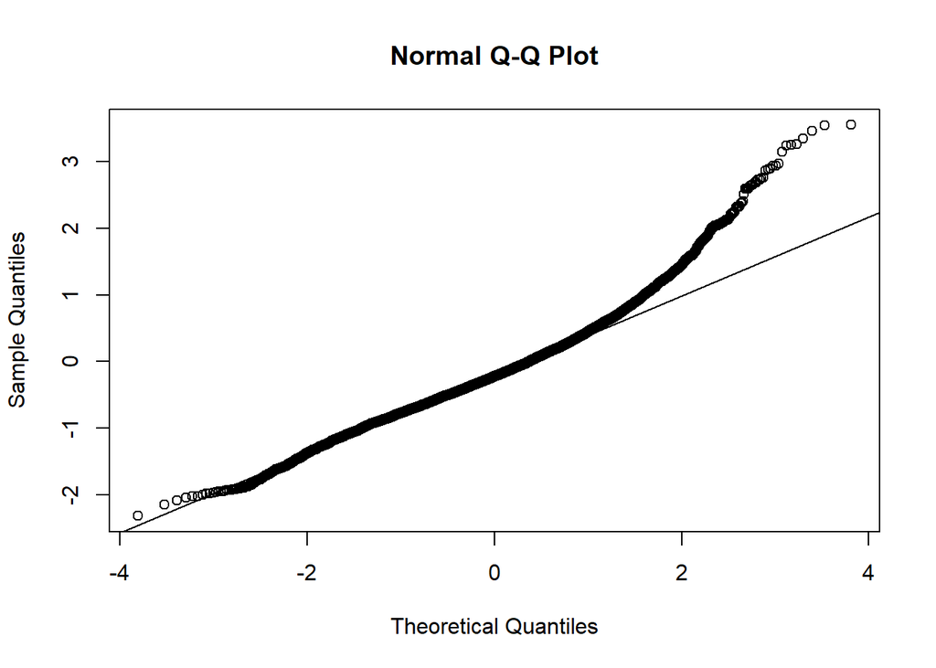

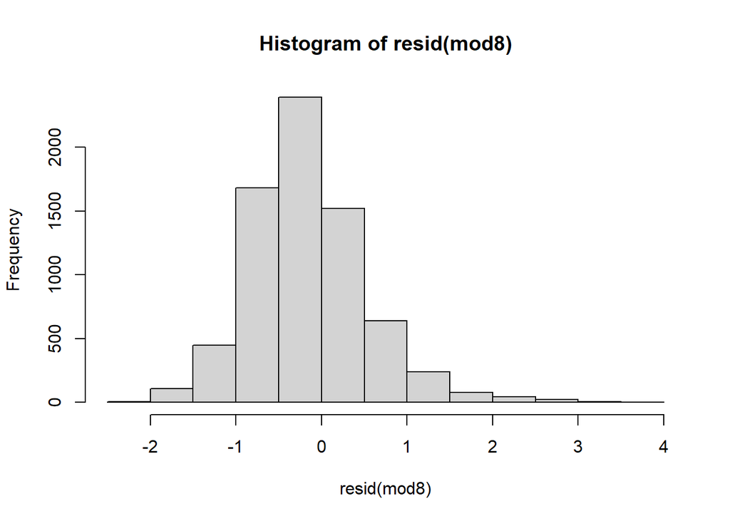

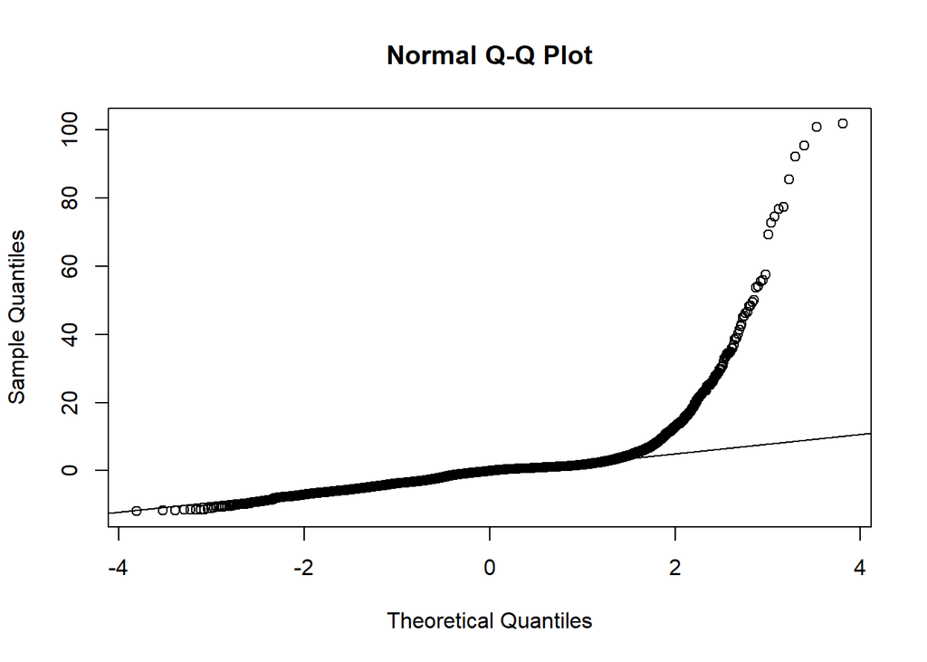

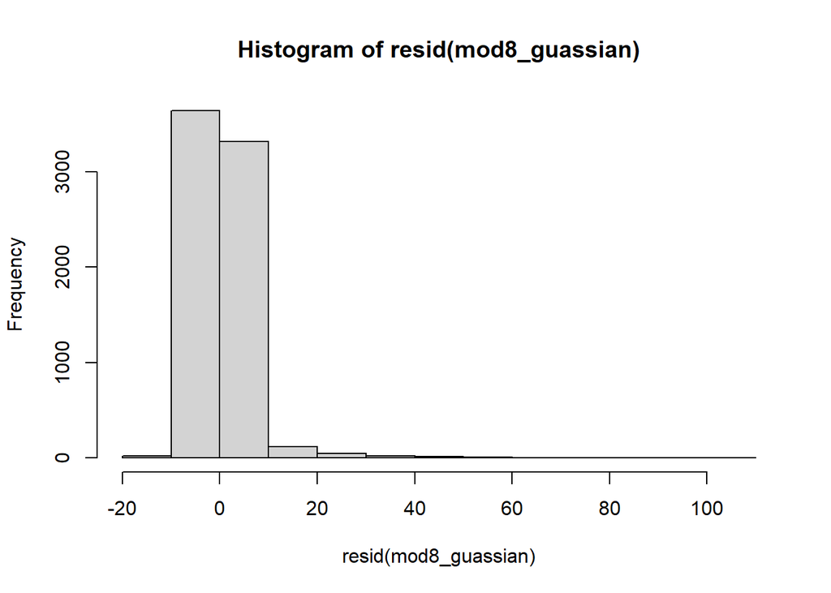